# SwiftKey Capstone: Exploratory Data Analysis

Miguel Rosa

2026-07-23

# 1. Dataset Overview

## 1.1 Source File Summary

The English SwiftKey dataset contains text from three sources: blogs, news articles, and tweets.

```r
summary_dt <- train[, .(
  Lines            = .N,
  Total_Words      = sum(str_count(text, "\\S+")),
  Mean_Words_Line  = round(mean(str_count(text, "\\S+")), 1),
  Median_Words_Line = round(median(str_count(text, "\\S+")), 1),
  Mean_Chars_Line  = round(mean(nchar(text)), 1)
), by = source]

knitr::kable(summary_dt, caption = "Summary statistics by source")
```

Summary statistics by source

| source | Lines | Total_Words | Mean_Words_Line | Median_Words_Line | Mean_Chars_Line |
| --- | --- | --- | --- | --- | --- |
| blogs | 809248 | 33534473 | 41.4 | 28 | 229.0 |
| news | 909216 | 30875976 | 34.0 | 31 | 200.8 |
| twitter | 2124133 | 27301754 | 12.9 | 12 | 68.6 |

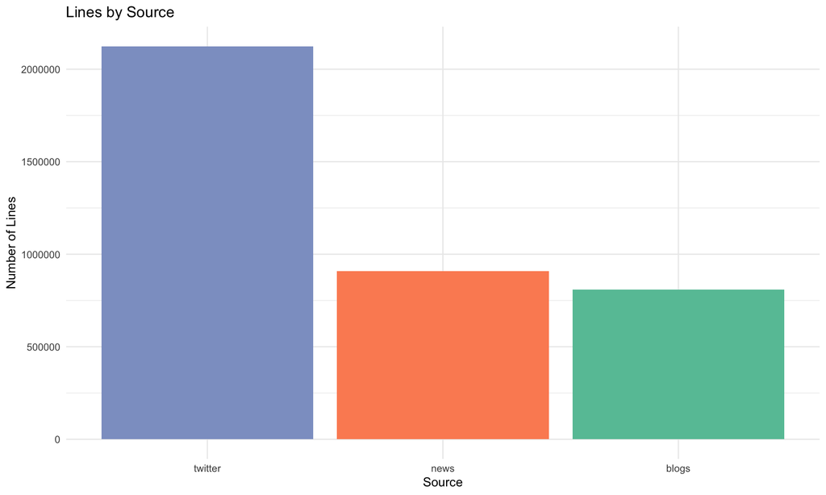

Number of lines by source

```r
ggplot(train, aes(x = reorder(source, -table(source)[source]), fill = source)) +
  geom_bar() +
  labs(x = "Source", y = "Number of Lines", title = "Lines by Source") +
  theme_minimal() +
  theme(legend.position = "none") +
  scale_fill_brewer(palette = "Set2")
```

## 1.2 Word Count Distribution

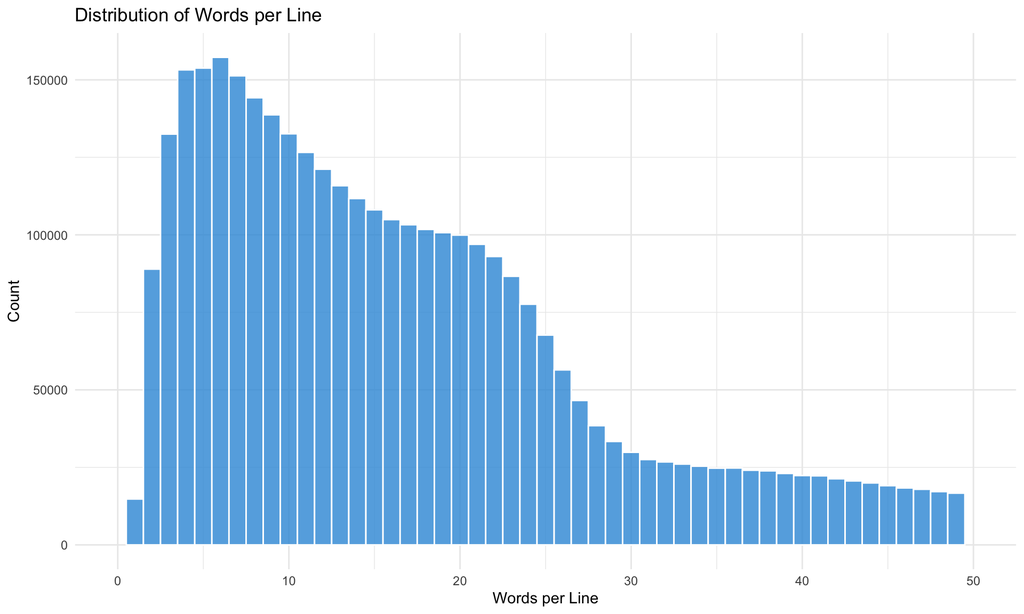

```r
train[, word_count := str_count(text, "\\S+")]

ggplot(train, aes(x = word_count)) +
  geom_histogram(binwidth = 1, fill = "#3498db", color = "white", alpha = 0.8) +
  xlim(0, 50) +
  labs(x = "Words per Line", y = "Count", title = "Distribution of Words per Line") +
  theme_minimal()
```

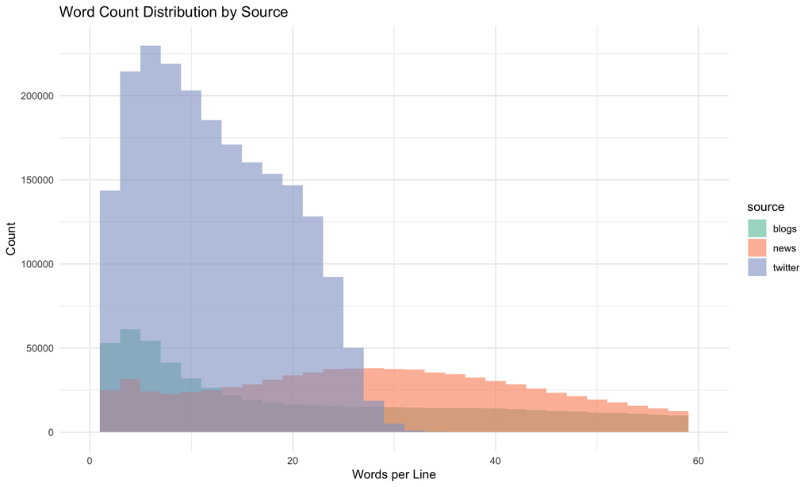

```r
ggplot(train, aes(x = word_count, fill = source)) +
  geom_histogram(binwidth = 2, alpha = 0.6, position = "identity") +
  xlim(0, 60) +
  labs(x = "Words per Line", y = "Count", title = "Word Count Distribution by Source") +
  theme_minimal() +
  scale_fill_brewer(palette = "Set2")
```

# 2. Word Frequency Analysis

## 2.1 Tokenize to Words

```r
all_words <- train[, unlist(str_extract_all(tolower(text), "\\b[a-z]+\\b"))]
cat("Total word tokens:", format(length(all_words), big.mark = ","), "\n")
```

```
## Total word tokens: 92,048,596
```

```r
cat("Unique word types:", format(length(unique(all_words)), big.mark = ","), "\n")
```

```
## Unique word types: 534,521
```

## 2.2 Word Frequency Table

```r
word_freq <- as.data.table(table(all_words))
setnames(word_freq, c("word", "count"))
word_freq <- word_freq[order(-count)]
word_freq[, rank := .I]
word_freq[, freq := count / sum(count)]

cat("Top 20 most frequent words:\n")
```

```
## Top 20 most frequent words:
```

```r
knitr::kable(head(word_freq, 20), caption = "Top 20 Words")
```

Top 20 Words

| word | count | rank | freq |
| --- | --- | --- | --- |
| the | 4292707 | 1 | 0.0466352 |
| to | 2485834 | 2 | 0.0270057 |
| and | 2178441 | 3 | 0.0236662 |
| a | 2169067 | 4 | 0.0235644 |
| of | 1809153 | 5 | 0.0196543 |
| i | 1761062 | 6 | 0.0191319 |
| in | 1492012 | 7 | 0.0162090 |
| that | 998684 | 8 | 0.0108495 |
| it | 993347 | 9 | 0.0107915 |
| for | 992595 | 10 | 0.0107834 |
| is | 967414 | 11 | 0.0105098 |
| you | 921558 | 12 | 0.0100116 |
| s | 760086 | 13 | 0.0082574 |
| on | 741670 | 14 | 0.0080574 |
| with | 643305 | 15 | 0.0069888 |
| was | 562262 | 16 | 0.0061083 |
| my | 544700 | 17 | 0.0059175 |
| at | 515879 | 18 | 0.0056044 |
| be | 494564 | 19 | 0.0053729 |
| this | 490515 | 20 | 0.0053289 |

## 2.3 Zipf’s Law

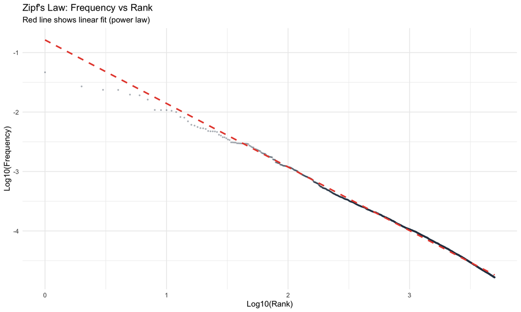

Zipf’s Law: Log-Log Plot of Word Frequency vs Rank

```r
ggplot(head(word_freq, 5000), aes(x = log10(rank), y = log10(freq))) +
  geom_point(alpha = 0.3, size = 0.5, color = "#2c3e50") +
  geom_smooth(method = "lm", se = FALSE, color = "#e74c3c", linetype = "dashed") +
  labs(x = "Log10(Rank)", y = "Log10(Frequency)",
       title = "Zipf's Law: Frequency vs Rank",
       subtitle = "Red line shows linear fit (power law)") +
  theme_minimal()
```

## 2.4 Word Length Distribution

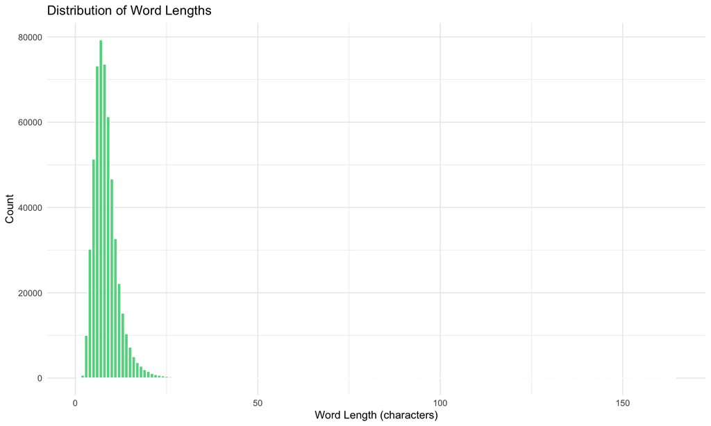

```r
word_lengths <- data.table(word = names(table(all_words)))
word_lengths[, nchar := nchar(word)]

ggplot(word_lengths, aes(x = nchar)) +
  geom_histogram(binwidth = 1, fill = "#2ecc71", color = "white", alpha = 0.8) +
  labs(x = "Word Length (characters)", y = "Count",
       title = "Distribution of Word Lengths") +
  theme_minimal()
```

# 3. N-Gram Analysis

```r
# Sample 5% for n-gram analysis
set.seed(42)
sample_idx <- sample(nrow(train), size = floor(0.05 * nrow(train)))
sample_text <- tolower(train[sample_idx, text])

# Tokenize: split each line into words, add sentence boundary markers
tokenize_line <- function(line) {
  words <- unlist(str_extract_all(line, "\\b[a-z]+\\b"))
  c("^", words, "$")
}

cat("Tokenizing sample...\n")
```

```
## Tokenizing sample...
```

```r
all_tokens <- unlist(lapply(sample_text, tokenize_line))
cat("Total tokens (incl. boundaries):", format(length(all_tokens), big.mark = ","), "\n")
```

```
## Total tokens (incl. boundaries): 4,980,658
```

```r
# Build n-grams from flat token vector
# For each position, grab the preceding words as context
build_ngrams <- function(tokens, n) {
  ngrams <- character(length(tokens) - n + 1)
  for (i in seq_len(length(tokens) - n + 1)) {
    ngrams[i] <- paste(tokens[i:(i + n - 1)], collapse = " ")
  }
  ngrams
}
```

## 3.1 Bigrams (2-grams)

```r
cat("Building bigrams...\n")
```

```
## Building bigrams...
```

```r
bigrams_raw <- build_ngrams(all_tokens, 2)

# Count frequencies
bigram_dt <- as.data.table(table(bigrams_raw))
setnames(bigram_dt, c("ngram", "count"))
bigram_dt <- bigram_dt[order(-count)]
bigram_dt[, freq := count / sum(count)]

cat("Top 20 bigrams:\n")
```

```
## Top 20 bigrams:
```

```r
knitr::kable(head(bigram_dt, 20), caption = "Top 20 Bigrams")
```

Top 20 Bigrams

| ngram | count | freq |
| --- | --- | --- |
| $ ^ | 192128 | 0.0385748 |
| of the | 19435 | 0.0039021 |
| in the | 18787 | 0.0037720 |
| ^ i | 17057 | 0.0034246 |
| ^ the | 10707 | 0.0021497 |
| to the | 9516 | 0.0019106 |
| for the | 9092 | 0.0018255 |
| on the | 8963 | 0.0017996 |
| i m | 8391 | 0.0016847 |
| it s | 8089 | 0.0016241 |
| to be | 7309 | 0.0014675 |
| at the | 6363 | 0.0012775 |
| and the | 5685 | 0.0011414 |
| don t | 5646 | 0.0011336 |
| in a | 5483 | 0.0011009 |
| with the | 4742 | 0.0009521 |
| is a | 4595 | 0.0009226 |
| it was | 4368 | 0.0008770 |
| for a | 4205 | 0.0008443 |
| and i | 4128 | 0.0008288 |

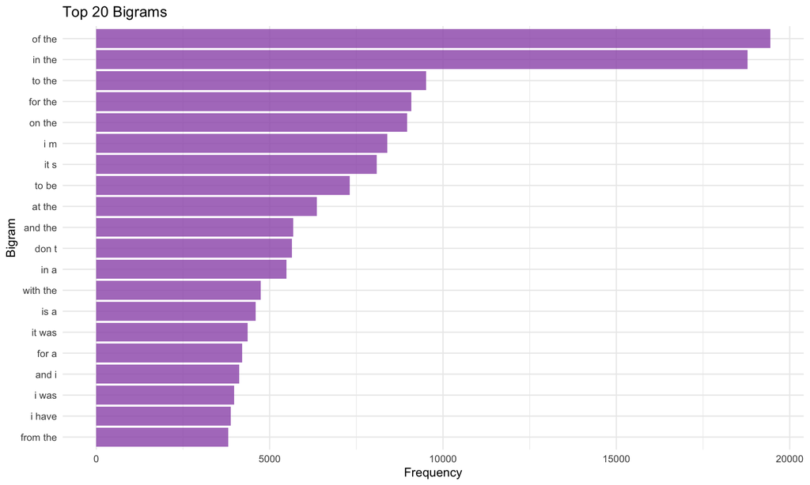

Top 20 Bigrams

```r
top_bg <- head(bigram_dt[!grepl("\\^|\\$", ngram)], 20)
ggplot(top_bg, aes(x = reorder(ngram, count), y = count)) +
  geom_col(fill = "#9b59b6", alpha = 0.8) +
  coord_flip() +
  labs(x = "Bigram", y = "Frequency", title = "Top 20 Bigrams") +
  theme_minimal()
```

## 3.2 Trigrams (3-grams)

```r
cat("Building trigrams...\n")
```

```
## Building trigrams...
```

```r
trigrams_raw <- build_ngrams(all_tokens, 3)

tri_dt <- as.data.table(table(trigrams_raw))
setnames(tri_dt, c("ngram", "count"))
tri_dt <- tri_dt[order(-count)]
tri_dt[, freq := count / sum(count)]

cat("Top 20 trigrams:\n")
```

```
## Top 20 trigrams:
```

```r
knitr::kable(head(tri_dt, 20), caption = "Top 20 Trigrams")
```

Top 20 Trigrams

| ngram | count | freq |
| --- | --- | --- |
| $ ^ i | 17057 | 0.0034246 |
| $ ^ the | 10707 | 0.0021497 |
| $ ^ it | 3670 | 0.0007369 |
| $ ^ we | 3025 | 0.0006073 |
| $ ^ you | 2931 | 0.0005885 |
| it $ ^ | 2928 | 0.0005879 |
| $ ^ thanks | 2441 | 0.0004901 |
| you $ ^ | 2360 | 0.0004738 |
| $ ^ in | 2321 | 0.0004660 |
| $ ^ a | 2171 | 0.0004359 |
| $ ^ so | 2159 | 0.0004335 |
| $ ^ if | 2083 | 0.0004182 |
| ^ i m | 2077 | 0.0004170 |
| $ ^ this | 2067 | 0.0004150 |
| $ ^ what | 2040 | 0.0004096 |
| me $ ^ | 1944 | 0.0003903 |
| i don t | 1934 | 0.0003883 |
| said $ ^ | 1915 | 0.0003845 |
| $ ^ and | 1909 | 0.0003833 |
| $ ^ that | 1904 | 0.0003823 |

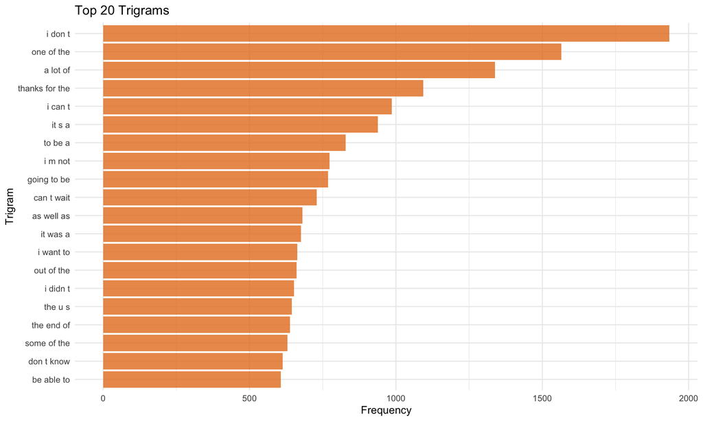

Top 20 Trigrams

```r
top_tri <- head(tri_dt[!grepl("\\^|\\$", ngram)], 20)
ggplot(top_tri, aes(x = reorder(ngram, count), y = count)) +
  geom_col(fill = "#e67e22", alpha = 0.8) +
  coord_flip() +
  labs(x = "Trigram", y = "Frequency", title = "Top 20 Trigrams") +
  theme_minimal()
```

## 3.3 Quadgrams (4-grams)

```r
cat("Building quadgrams...\n")
```

```
## Building quadgrams...
```

```r
quadgrams_raw <- build_ngrams(all_tokens, 4)

quad_dt <- as.data.table(table(quadgrams_raw))
setnames(quad_dt, c("ngram", "count"))
quad_dt <- quad_dt[order(-count)]
quad_dt[, freq := count / sum(count)]

cat("Top 15 quadgrams:\n")
```

```
## Top 15 quadgrams:
```

```r
knitr::kable(head(quad_dt, 15), caption = "Top 15 Quadgrams")
```

Top 15 Quadgrams

| ngram | count | freq |
| --- | --- | --- |
| $ ^ i m | 2077 | 0.0004170 |
| $ ^ it s | 1659 | 0.0003331 |
| $ ^ thanks for | 1311 | 0.0002632 |
| $ ^ thank you | 929 | 0.0001865 |
| $ ^ if you | 856 | 0.0001719 |
| ^ thanks for the | 836 | 0.0001678 |
| $ ^ i love | 764 | 0.0001534 |
| $ ^ i have | 753 | 0.0001512 |
| $ ^ i think | 723 | 0.0001452 |
| $ ^ that s | 677 | 0.0001359 |
| $ ^ i am | 674 | 0.0001353 |
| $ ^ this is | 627 | 0.0001259 |
| $ ^ in the | 533 | 0.0001070 |
| ^ i don t | 532 | 0.0001068 |
| $ ^ i don | 532 | 0.0001068 |

# 4. Vocabulary Coverage

## 4.1 How Many Words to Cover X% of Instances?

```r
word_freq[, cum_freq := cumsum(freq)]

coverage_targets <- c(0.50, 0.75, 0.90, 0.95, 0.99)
coverage_n <- sapply(coverage_targets, function(t) {
  min(word_freq[cum_freq >= t, rank])
})

coverage_df <- data.frame(
  Target              = paste0(coverage_targets * 100, "%"),
  Unique_Words_Needed = coverage_n,
  Pct_of_Vocabulary   = round(coverage_n / nrow(word_freq) * 100, 2)
)

knitr::kable(coverage_df,
             caption = "Unique words needed to cover X% of all word instances",
             col.names = c("Coverage Target", "Unique Words Needed", "% of Vocabulary"))
```

Unique words needed to cover X% of all word instances

| Coverage Target | Unique Words Needed | % of Vocabulary |
| --- | --- | --- |
| 50% | 130 | 0.02 |
| 75% | 1367 | 0.26 |
| 90% | 6849 | 1.28 |
| 95% | 16022 | 3.00 |
| 99% | 83662 | 15.65 |

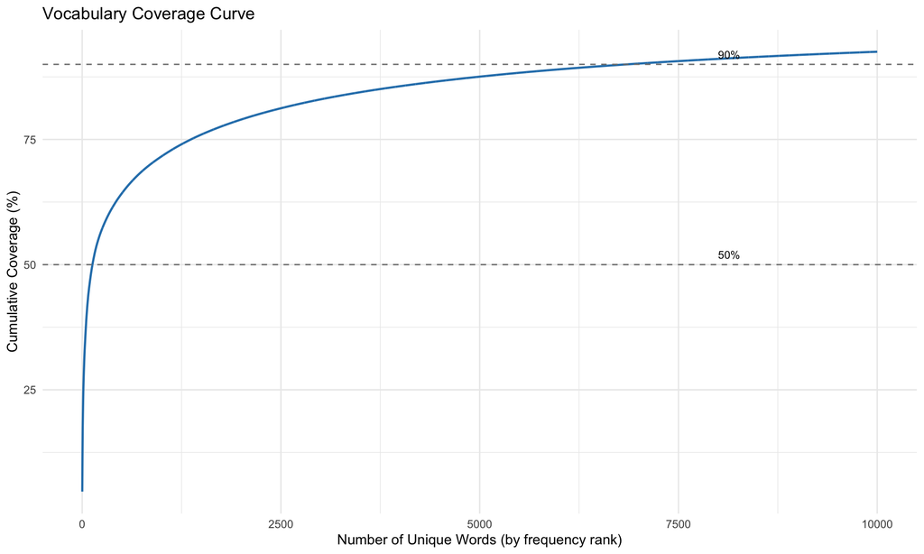

Cumulative Coverage by Number of Unique Words

```r
ggplot(head(word_freq, 10000), aes(x = rank, y = cum_freq * 100)) +
  geom_line(color = "#2980b9", linewidth = 0.8) +
  geom_hline(yintercept = 50, linetype = "dashed", color = "grey50") +
  geom_hline(yintercept = 90, linetype = "dashed", color = "grey50") +
  annotate("text", x = 8000, y = 52, label = "50%", hjust = 0, size = 3) +
  annotate("text", x = 8000, y = 92, label = "90%", hjust = 0, size = 3) +
  labs(x = "Number of Unique Words (by frequency rank)",
       y = "Cumulative Coverage (%)",
       title = "Vocabulary Coverage Curve") +
  theme_minimal()
```

## 4.2 Heaps’ Law (Vocabulary Growth)

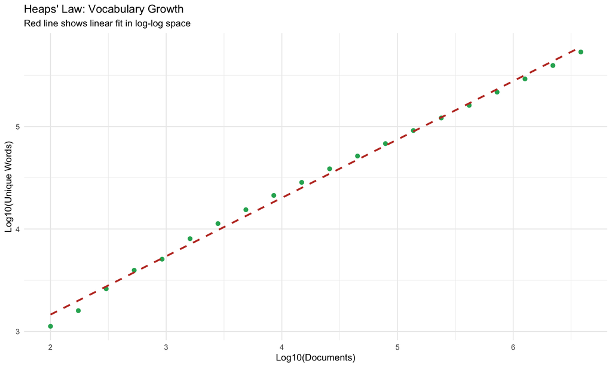

```r
sample_sizes <- floor(10^seq(2, log10(nrow(train)), length.out = 20))
growth <- data.table()

for (sz in sample_sizes) {
  idx <- sample(nrow(train), size = sz)
  words <- unlist(str_extract_all(tolower(train[idx, text]), "\\b[a-z]+\\b"))
  vocab <- length(unique(words))
  growth <- rbind(growth, data.table(n = sz, vocab = vocab))
}

ggplot(growth, aes(x = log10(n), y = log10(vocab))) +
  geom_point(color = "#27ae60", size = 2) +
  geom_smooth(method = "lm", se = FALSE, color = "#c0392b", linetype = "dashed") +
  labs(x = "Log10(Documents)", y = "Log10(Unique Words)",
       title = "Heaps' Law: Vocabulary Growth",
       subtitle = "Red line shows linear fit in log-log space") +
  theme_minimal()
```

# 5. Profanity and Foreign Words

## 5.1 Profanity Check

```r
profanity_words <- c("fuck", "shit", "ass", "bitch", "damn", "hell",
                     "crap", "dick", "piss", "bastard", "whore", "slut")

profanity_freq <- word_freq[word %in% profanity_words]

cat("Profanity words found:", nrow(profanity_freq), "\n")
```

```
## Profanity words found: 12
```

```r
if (nrow(profanity_freq) > 0) {
  knitr::kable(profanity_freq, caption = "Profanity word frequencies")
}
```

Profanity word frequencies

| word | count | rank | freq | cum_freq |
| --- | --- | --- | --- | --- |
| shit | 17899 | 555 | 0.0001945 | 0.6538002 |
| hell | 13445 | 735 | 0.0001461 | 0.6839590 |
| ass | 13130 | 748 | 0.0001426 | 0.6858374 |
| damn | 12739 | 766 | 0.0001384 | 0.6883718 |
| fuck | 12462 | 778 | 0.0001354 | 0.6900131 |
| bitch | 7969 | 1236 | 0.0000866 | 0.7392463 |
| dick | 3761 | 2436 | 0.0000409 | 0.8097808 |
| crap | 3729 | 2451 | 0.0000405 | 0.8103902 |
| piss | 996 | 6776 | 0.0000108 | 0.8992175 |
| whore | 752 | 8213 | 0.0000082 | 0.9127377 |
| slut | 562 | 9896 | 0.0000061 | 0.9246169 |
| bastard | 549 | 10032 | 0.0000060 | 0.9254373 |

## 5.2 Non-English / Foreign Words

```r
hapax <- word_freq[count == 1]
cat("Hapax legomena (words appearing once):", nrow(hapax),
    "(", round(nrow(hapax) / nrow(word_freq) * 100, 1), "% of vocabulary)\n")
```

```
## Hapax legomena (words appearing once): 285110 ( 53.3 % of vocabulary)
```

```r
foreign_heuristic <- word_freq[str_detect(word, "[^a-z]")]
cat("Words with non-standard chars:", nrow(foreign_heuristic), "\n")
```

```
## Words with non-standard chars: 0
```

# 6. Source-Specific Word Frequencies

[figure not shown]

```r
top_words_by_source <- lapply(c("blogs", "news", "twitter"), function(src) {
  words <- unlist(str_extract_all(tolower(train[source == src, text]), "\\b[a-z]+\\b"))
  freq <- as.data.table(sort(table(words), decreasing = TRUE))
  setnames(freq, c("word", "count"))
  freq[, source := src]
  freq[, rank := .I]
  head(freq, 30)
})

all_top <- rbindlist(top_words_by_source)

ggplot(all_top, aes(x = reorder(word, -count), y = count, fill = source)) +
  geom_col(alpha = 0.8, position = "dodge") +
  facet_wrap(~source, scales = "free_y", ncol = 1) +
  coord_flip() +
  labs(x = "Word", y = "Frequency", title = "Top 30 Words by Source") +
  theme_minimal() +
  theme(legend.position = "none") +
  scale_fill_brewer(palette = "Set2")
```

# 7. Key Findings

```r
cat("═══════════════════════════════════════════════════════\n")
```

```
## ═══════════════════════════════════════════════════════
```

```r
cat("KEY FINDINGS\n")
```

```
## KEY FINDINGS
```

```r
cat("═══════════════════════════════════════════════════════\n\n")
```

```
## ═══════════════════════════════════════════════════════
```

```r
cat("1. DATA SIZE\n")
```

```
## 1. DATA SIZE
```

```r
cat("   - Training set:", format(nrow(train), big.mark = ","), "lines\n")
```

```
##    - Training set: 3,842,597 lines
```

```r
cat("   - Test set:", format(nrow(test), big.mark = ","), "lines\n\n")
```

```
##    - Test set: 426,957 lines
```

```r
cat("2. VOCABULARY\n")
```

```
## 2. VOCABULARY
```

```r
cat("   - Unique words:", format(nrow(word_freq), big.mark = ","), "\n")
```

```
##    - Unique words: 534,521
```

```r
cat("   - Total tokens:", format(sum(word_freq$count), big.mark = ","), "\n")
```

```
##    - Total tokens: 92,048,596
```

```r
cat("   - 50% coverage requires", coverage_n[1], "unique words\n")
```

```
##    - 50% coverage requires 130 unique words
```

```r
cat("   - 90% coverage requires", coverage_n[3], "unique words\n\n")
```

```
##    - 90% coverage requires 6849 unique words
```

```r
cat("3. TOP WORDS\n")
```

```
## 3. TOP WORDS
```

```r
cat("   - Most common:", head(word_freq$word, 5), "\n")
```

```
##    - Most common: the to and a of
```

```r
cat("   - Top 100 words cover", round(word_freq[100, cum_freq] * 100, 1), "% of tokens\n\n")
```

```
##    - Top 100 words cover 47 % of tokens
```

```r
cat("4. N-GRAM OBSERVATIONS\n")
```

```
## 4. N-GRAM OBSERVATIONS
```

```r
cat("   - Top bigram:", head(bigram_dt[!grepl("\\^|\\$", ngram)]$ngram, 1), "\n")
```

```
##    - Top bigram: of the
```

```r
cat("   - Top trigram:", head(tri_dt[!grepl("\\^|\\$", ngram)]$ngram, 1), "\n")
```

```
##    - Top trigram: i don t
```

```r
cat("   - Many top n-grams are stopword combinations\n\n")
```

```
##    - Many top n-grams are stopword combinations
```

```r
cat("5. SOURCE DIFFERENCES\n")
```

```
## 5. SOURCE DIFFERENCES
```

```r
cat("   - Twitter has shortest average lines\n")
```

```
##    - Twitter has shortest average lines
```

```r
cat("   - News has most formal vocabulary\n")
```

```
##    - News has most formal vocabulary
```

```r
cat("   - Blogs are most diverse in word choice\n")
```

```
##    - Blogs are most diverse in word choice
```

# 8. Plans for the Prediction Algorithm and Shiny App

This section summarizes, in plain terms, how the exploration above translates into a working product.

**The algorithm.** The app will guess the next word as you type, the same way a phone keyboard does. It works by looking at the last few words you typed and finding what word most commonly comes next in the training data — first checking the last 3 words, and falling back to the last 2, then the last 1, then just the most common words overall if nothing matches. This approach (called “Stupid Backoff”) is a standard, well-tested technique that is simple, fast, and doesn’t require complex statistical tuning.

**Managing size and speed.** Sections 4–5 showed the vocabulary is large but long-tailed (hundreds of thousands of words, most used only once). Rare words will be grouped into a single “unknown” placeholder, and only the top few candidate next-words will be kept per phrase. This keeps the final model small enough to run instantly in a web browser rather than needing a large, slow lookup table.

**The app.** The end product will be a Shiny web app: a single text box where a user types a phrase, and the three most likely next words appear as clickable buttons — clicking one appends it to the phrase, just like a phone keyboard’s suggestion bar.

**How we’ll know it’s good.** Before release, the model will be tested on text it has never seen, measuring how often the actual next word appears in its top 1, 2, or 3 guesses, plus how fast each prediction takes (target: comfortably under 100ms, well below what a user would notice).

*Report generated with R 4.6.1 on 2026-07-23.*